# Refined_Version

Jabir Ghaffar

2024-09-12

# Final Datatrail Project

### Your objectives!

To complete this project, there are a few requirements you will need to fulfill. Remember that you are not on your own for this project! Data science is done best as a community, so please ask others (and instructors) questions when you get stuck!

1. Clearly state the data science question and goal for the analysis you are embarking on.
2. This project should be completely uploaded and up to date on GitHub.
3. Follow good organization principles – you should at least have 2 folders: a `results` folder and a `data` folder.
4. Make a resulting plot that you save to a file.
5. Write up your final observations.
6. Share your GitHub link for project review.

## Data

For this project, I chose gaming data from the TidyTuesday project.

Source of data: [Games Dataset](https://github.com/rfordatascience/tidytuesday/blob/master/data/2021/2021-03-16/readme.md#gamescsv)

The dataset contains player statistics for various games on Steam, including average players per game per month.

## The goal of this analysis

The goal of this analysis is to identify which gaming companies are runner-ups to the big companies dominating the gaming space. I also want to see how certain games (like Counter-Strike: Global Offensive) perform over time compared to other games.

## Set up

What gaming companies are runner-ups to the big companies?

### Load packages

```r
library(tidyverse)
```

```r
library(readr)
library(dplyr)
library(ggplot2)
library(tidyr)
library(usethis)
```

### Set up directories

```r
if (!dir.exists("data")) {
  dir.create("data")
}
if (!dir.exists("results")) {
  dir.create("results")
}
```

## Get the data

```r
games <- readr::read_csv('https://raw.githubusercontent.com/rfordatascience/tidytuesday/master/data/2021/2021-03-16/games.csv')
```

### Explore the data

```r
glimpse(games)
```

```
## Rows: 83,631
## Columns: 7
## $ gamename      <chr> "Counter-Strike: Global Offensive", "Dota 2", "PLAYERUNK…
## $ year          <dbl> 2021, 2021, 2021, 2021, 2021, 2021, 2021, 2021, 2021, 20…
## $ month         <chr> "February", "February", "February", "February", "Februar…
## $ avg           <dbl> 741013.24, 404832.13, 198957.52, 120982.64, 117742.27, 1…
## $ gain          <dbl> -2196.42, -27839.52, -2289.67, 49215.90, -24374.98, 1808…
## $ peak          <dbl> 1123485, 651615, 447390, 196799, 224276, 133620, 146438,…
## $ avg_peak_perc <chr> "65.9567%", "62.1275%", "44.4707%", "61.4752%", "52.4988…
```

## Data Cleaning

```r
games_tidy <- games %>%
  filter(gamename %in% c("Counter-Strike: Global Offensive", "Dota 2",
                         "PLAYERUNKNOWN'S BATTLEGROUNDS", "Rust", "Apex Legends",
                         "Grand Theft Auto V", "Team Fortress 2", "Cyberpunk 2077",
                         "Tom Clancy's Rainbow Six Siege", "ARK: Survival Evolved")) %>%
  filter(year == 2021) %>%
  select(gamename, avg, month, year) %>%
  slice_max(order_by = avg, n = 15) %>%
  arrange(desc(avg))
```

## Plot the data!

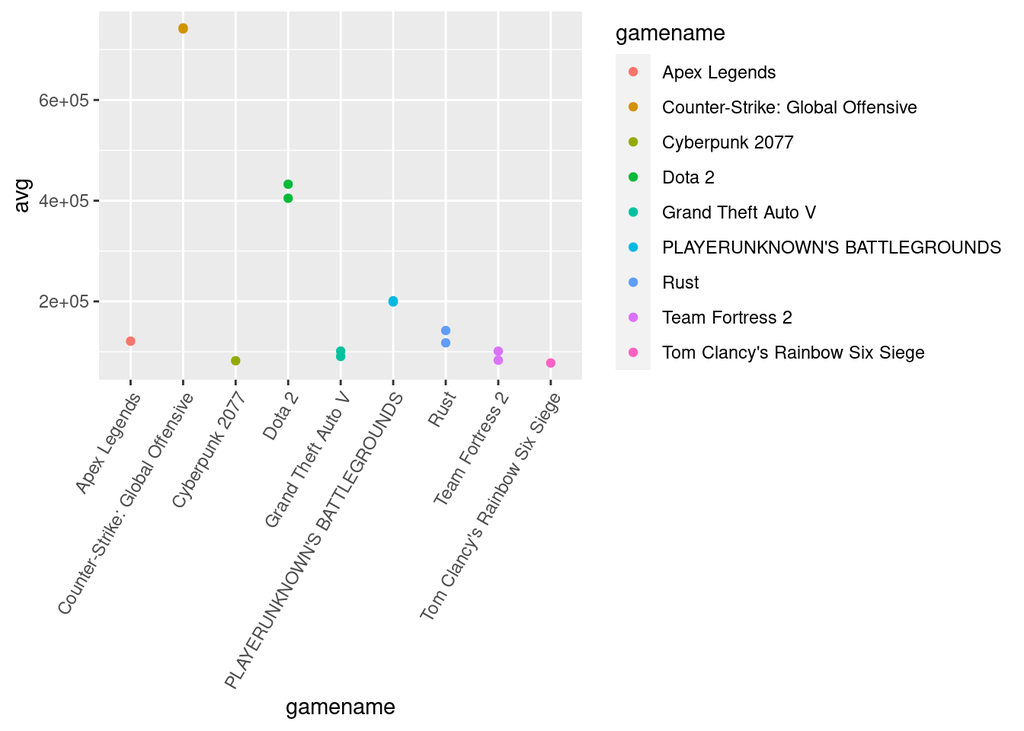

```r
games_tidy_plot <- ggplot(data = games_tidy) +
  geom_point(aes(x = gamename, y = avg, color = gamename)) +
  theme(axis.text.x = element_text(angle = 60, hjust = 1))

games_tidy_plot
```

```r
ggsave("results/results.pdf", plot = games_tidy_plot)
```

From this plot, I can see that Counter-Strike: Global Offensive is the top game being played in 2021.

### Investigating Counter-Strike’s popularity over time

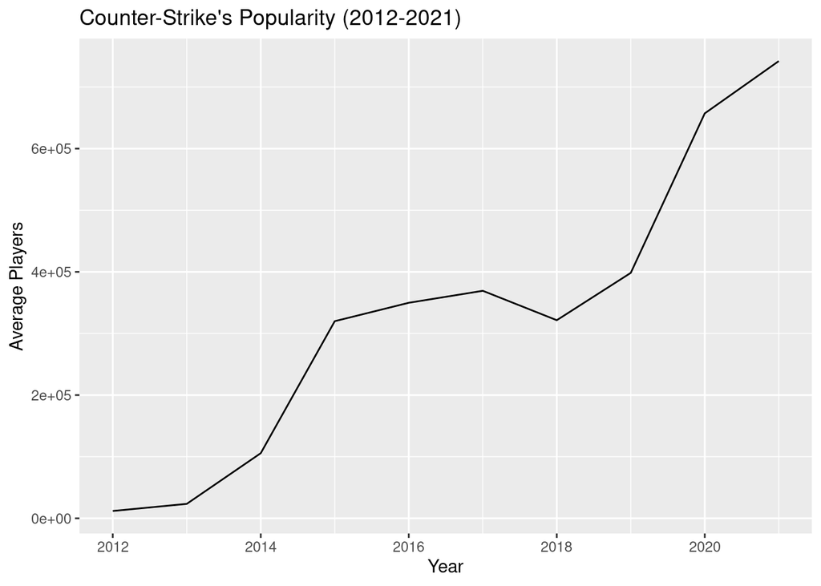

```r
csgo_data <- games %>%
  filter(gamename == "Counter-Strike: Global Offensive") %>%
  filter(year >= 2012 & year <= 2021) %>%
  group_by(year) %>%
  summarise(mean_pop = mean(avg, na.rm = TRUE))

ggplot(csgo_data, aes(x = year, y = mean_pop)) +
  geom_line() +
  labs(title = "Counter-Strike's Popularity (2012-2021)",
       x = "Year", y = "Average Players")
```

### Comparing Counter-Strike to all other games (2012-2021)

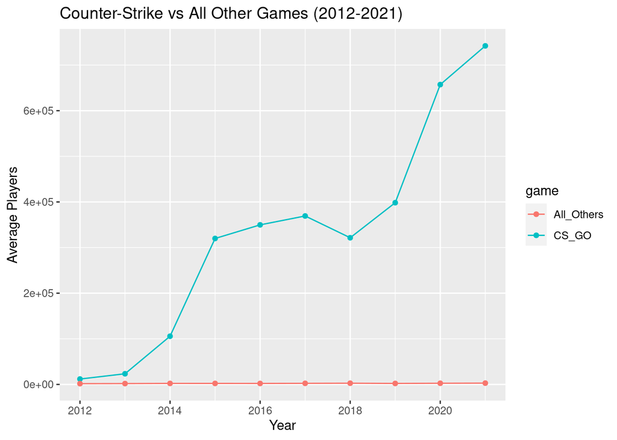

```r
other_games_data <- games %>%
  filter(gamename != "Counter-Strike: Global Offensive", year >= 2012, year <= 2021) %>%
  group_by(year) %>%
  summarise(mean_pop = mean(avg, na.rm = TRUE))

comparison_plot <- bind_rows(list(CS_GO = csgo_data, All_Others = other_games_data), .id = "game") %>%
  ggplot(aes(x = year, y = mean_pop, color = game)) +
  geom_point() +
  geom_line() +
  labs(title = "Counter-Strike vs All Other Games (2012-2021)",
       x = "Year", y = "Average Players")

comparison_plot
```

## Get the stats

```r
summary(games_tidy)
```

```
##    gamename              avg            month                year
##  Length:15          Min.   : 77717   Length:15          Min.   :2021
##  Class :character   1st Qu.: 95939   Class :character   1st Qu.:2021
##  Mode  :character   Median :120983   Mode  :character   Median :2021
##                     Mean   :242594                      Mean   :2021
##                     3rd Qu.:303040                      3rd Qu.:2021
##                     Max.   :743210                      Max.   :2021
```

## Conclusion

### Caveats:

- This data represents only a portion of 2021 and is specific to the Steam platform.
- It is unclear how representative this data is for other platforms and game markets.

### Follow-up questions:

- What games are peaking now in terms of player count?
- Are any of these games still maintaining the same player base today?

### **GitHub**

You can find my other experiences on my GitHub here: [My Career](https://github.com/jabirG/My-Career).